# PML

Akansh

10/24/2020

# AIM

To use data from accelerometers of belt, forearm, arm, and dumbell of 6 participants.

# Loading the necessary libraries.

```r
library(caret)
library(randomForest)
library(rpart.plot)
library(corrplot)
library(e1071)
library(rattle)
library(Amelia)
library(rpart)
library(caTools)
```

# Data

```r
testingData<-read.csv("pml-testing.csv")
trainingData<-read.csv("pml-training.csv")
dim(trainingData)
```

```
## [1] 19622   160
```

There are 160 variables and 19622 observations in the training set given.

## Cleaning Data

In this training dataset, most of the variables have missing values and unnescessary data which we need to get rid of first. So, we first have to clean our data.

### Splitting training set into testing and training sets

```r
set.seed(12345)
data_sample<-sample.split(trainingData$classe,SplitRatio = 0.8)
trainSet<-subset(trainingData,data_sample==TRUE)
testSet<-subset(trainingData,data_sample==FALSE)
dim(trainSet)
```

```
## [1] 15699   160
```

```r
dim(testSet)
```

```
## [1] 3923  160
```

### Removing variables with Nearly Zero Variance

```r
near0 <- nearZeroVar(trainingData)
trainSet <- trainSet[, -near0]
testSet  <- testSet[, -near0]
dim(trainSet)
```

```
## [1] 15699   100
```

```r
dim(testSet)
```

```
## [1] 3923  100
```

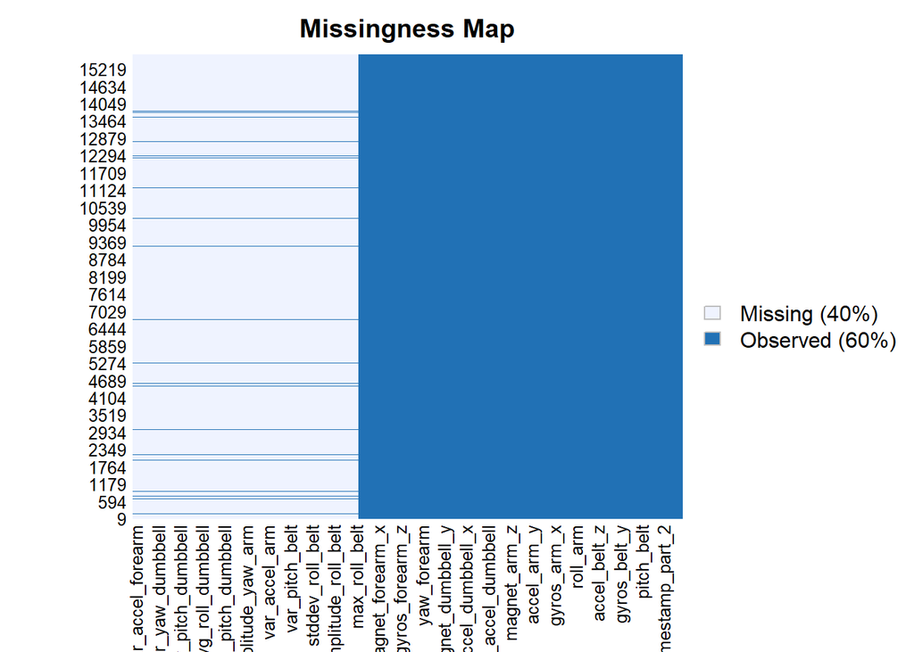

```r
# Checking the missing value percentage
missmap(trainSet)
```

It is observed that there is 40% of Missing data in the latest Training set. So, we have to get rid of that to get a reasonably good prediction model.

### Removing variables with missing(NA) values

```r
naValues    <- sapply(trainSet, function(x) mean(is.na(x))) > 0.95
trainSet <- trainSet[, naValues ==FALSE]
testSet  <- testSet[, naValues ==FALSE]
dim(trainSet)
```

```
## [1] 15699    59
```

```r
dim(testSet)
```

```
## [1] 3923   59
```

### Remove identification only variables i.e columns 1 to 5

```r
trainSet <- trainSet[, -(1:5)]
testSet  <- testSet[, -(1:5)]
dim(trainSet)
```

```
## [1] 15699    54
```

```r
dim(testSet)
```

```
## [1] 3923   54
```

Now we are left with the variables which are reasonable for us to build the model. Before that we first analyze the correaltion between these variables.

### Again Checking the Missing data Percentage of the Latest Data

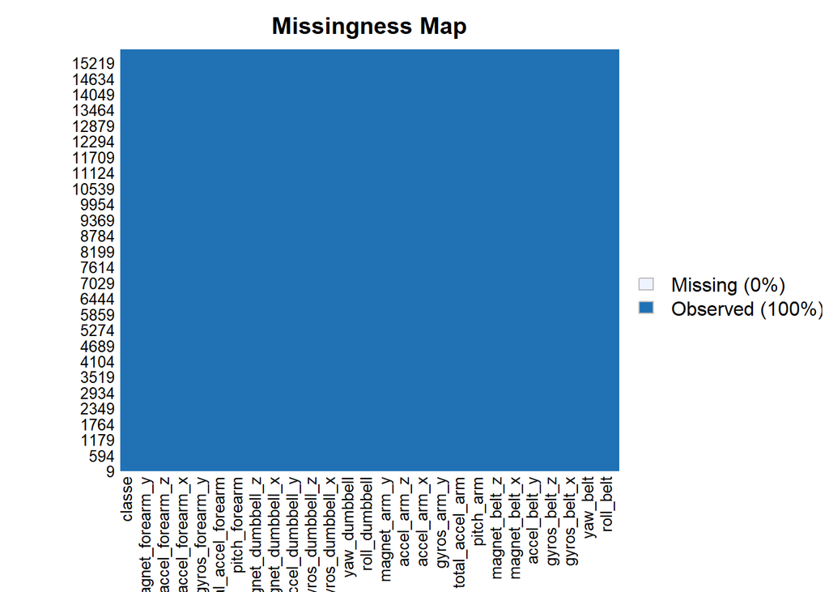

```r
missmap(trainSet)
```

We should note that there is Absolutely no Missing Data in our Training Set. Hence we can confidently go ahead with creating the prediction model but before that we check the correlation between variables to help predict with correct Independent variables.

### Checking the Null Hypothesis

Logistic<-lm(classe~., data=trainSet)

summary(Logistic)

## Correlation Among The Variables

Plotting the correlation if the variables in the training set

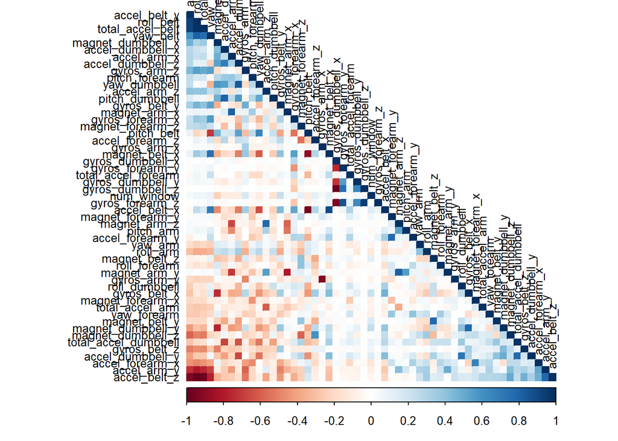

```r
correlation<-cor(trainSet[, -length(names(trainSet))])
corrplot(correlation, order = "FPC", method = "color", type = "lower",
         tl.cex = 0.8, tl.col = rgb(0, 0, 0))
```

The dark colors in the graph above represents the highly correlated variables.

# Testing Models for Prediction

## A) Decision Tree Prediction

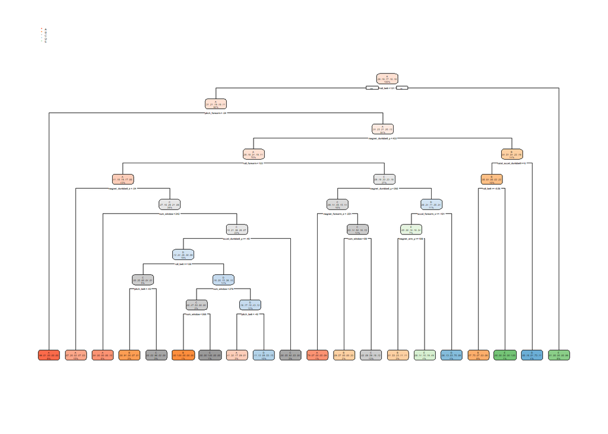

```r
WeareModTree<-rpart(classe~.,trainSet,method="class")
rpart.plot(WeareModTree)
```

```r
# Predicting testset result using the above model
predictTree<-predict(WeareModTree, newdata=testSet,type="class")
ToomuchconfTree<-confusionMatrix(predictTree,testSet$classe)
ToomuchconfTree
```

```
## Confusion Matrix and Statistics
##
##           Reference
## Prediction    A    B    C    D    E
##          A 1004  176   32   69   42
##          B   28  421   45   24   69
##          C   15   49  554  103   61
##          D   56   85   34  426   85
##          E   13   28   19   21  464
##
## Overall Statistics
##
##                Accuracy : 0.7313
##                  95% CI : (0.7172, 0.7452)
##     No Information Rate : 0.2845
##     P-Value [Acc > NIR] : < 2.2e-16
##
##                   Kappa : 0.6582
##
##  Mcnemar's Test P-Value : < 2.2e-16
##
## Statistics by Class:
##
##                      Class: A Class: B Class: C Class: D Class: E
## Sensitivity            0.8996   0.5547   0.8099   0.6625   0.6436
## Specificity            0.8864   0.9475   0.9296   0.9207   0.9747
## Pos Pred Value         0.7589   0.7172   0.7084   0.6210   0.8514
## Neg Pred Value         0.9569   0.8987   0.9586   0.9330   0.9239
## Prevalence             0.2845   0.1935   0.1744   0.1639   0.1838
## Detection Rate         0.2559   0.1073   0.1412   0.1086   0.1183
## Detection Prevalence   0.3372   0.1496   0.1993   0.1749   0.1389
## Balanced Accuracy      0.8930   0.7511   0.8698   0.7916   0.8091
```

## B) Random Forest Prediction

LOCbush <- trainControl(method=“cv”, number=3, verboseIter=FALSE)

RaceCar <- train(classe ~ ., data=trainSet, method=“rf”, trControl=LOCbush)

RaceCar$finalModel

predictRf <- predict(RaceCar , newdata=testSet)

FullconfRf<-confusionMatrix(predictRf,testSet$classe)

# Applying Approriate Model to the Test Dataset

```r
# As the Random Forest model is appropriate to use but due to the very sluggish rendering of the results with not so compatible system RAM, I am predicting the results using the Decision Tree Model
predictTestResults<-predict(WeareModTree,newdata=testingData, type="class" )
predictTestResults
```

```
##  1  2  3  4  5  6  7  8  9 10 11 12 13 14 15 16 17 18 19 20
##  B  A  B  A  A  C  D  D  A  A  C  B  C  A  E  D  A  A  A  B
## Levels: A B C D E
```